# Project Python Foundations: FoodHub Data Analysis (by **Maneesh Anand K.N.**)

### Context

The number of restaurants in New York is increasing day by day. Lots of students and busy professionals rely on those restaurants due to their hectic lifestyles. Online food delivery service is a great option for them. It provides them with good food from their favorite restaurants. A food aggregator company FoodHub offers access to multiple restaurants through a single smartphone app.

The app allows the restaurants to receive a direct online order from a customer. The app assigns a delivery person from the company to pick up the order after it is confirmed by the restaurant. The delivery person then uses the map to reach the restaurant and waits for the food package. Once the food package is handed over to the delivery person, he/she confirms the pick-up in the app and travels to the customer's location to deliver the food. The delivery person confirms the drop-off in the app after delivering the food package to the customer. The customer can rate the order in the app. The food aggregator earns money by collecting a fixed margin of the delivery order from the restaurants.

### Objective

The food aggregator company has stored the data of the different orders made by the registered customers in their online portal. They want to analyze the data to get a fair idea about the demand of different restaurants which will help them in enhancing their customer experience. Suppose you are hired as a Data Scientist in this company and the Data Science team has shared some of the key questions that need to be answered. Perform the data analysis to find answers to these questions that will help the company to improve the business.

### Data Description

The data contains the different data related to a food order. The detailed data dictionary is given below.

### Data Dictionary

- order_id: Unique ID of the order
- customer_id: ID of the customer who ordered the food
- restaurant_name: Name of the restaurant
- cuisine_type: Cuisine ordered by the customer
- cost_of_the_order: Cost of the order
- day_of_the_week: Indicates whether the order is placed on a weekday or weekend (The weekday is from Monday to Friday and the weekend is Saturday and Sunday)
- rating: Rating given by the customer out of 5
- food_preparation_time: Time (in minutes) taken by the restaurant to prepare the food. This is calculated by taking the difference between the timestamps of the restaurant's order confirmation and the delivery person's pick-up confirmation.
- delivery_time: Time (in minutes) taken by the delivery person to deliver the food package. This is calculated by taking the difference between the timestamps of the delivery person's pick-up confirmation and drop-off information

### Let us start by importing the required libraries

```python
# Installing the libraries with the specified version.
#!pip install numpy==1.25.2 pandas==1.5.3 matplotlib==3.7.1 seaborn==0.13.1 -q --user
```

**Note**: *After running the above cell, kindly restart the notebook kernel and run all cells sequentially from the start again.*

```python
# import libraries for data manipulation
import numpy as np
import pandas as pd

# import libraries for data visualization
import matplotlib.pyplot as plt
import seaborn as sns
```

### Understanding the structure of the data

```python
# uncomment and run the following lines for Google Colab
# from google.colab import drive
# drive.mount('/content/drive')

#Specific to my environment/folder structure
from google.colab import drive
drive.mount('/content/drive',force_remount = True)
```

```python
# Write your code here to read the data

#Specific to my environment/folder structure. Define the folder/directory path
FOLDER_PATH = '/content/drive/MyDrive/Colab_Notebooks/FoodHub_Project/'

#print(FOLDER_PATH)

#read the foodhub_order csv file into the pandas dataframe
df = pd.read_csv(FOLDER_PATH+'foodhub_order.csv')
```

```python
# Write your code here to view the first 5 rows
df.head(5)
```

|  | order_id | customer_id | restaurant_name | cuisine_type | cost_of_the_order | day_of_the_week | rating | food_preparation_time | delivery_time |
| --- | --- | --- | --- | --- | --- | --- | --- | --- | --- |
| 0 | 1477147 | 337525 | Hangawi | Korean | 30.75 | Weekend | Not given | 25 | 20 |
| 1 | 1477685 | 358141 | Blue Ribbon Sushi Izakaya | Japanese | 12.08 | Weekend | Not given | 25 | 23 |
| 2 | 1477070 | 66393 | Cafe Habana | Mexican | 12.23 | Weekday | 5 | 23 | 28 |
| 3 | 1477334 | 106968 | Blue Ribbon Fried Chicken | American | 29.20 | Weekend | 3 | 25 | 15 |
| 4 | 1478249 | 76942 | Dirty Bird to Go | American | 11.59 | Weekday | 4 | 25 | 24 |

### **Question 1:** How many rows and columns are present in the data? [0.5 mark]

```python
# Write your code here
# Shape of the dataset
# df.shape
print("Number of rows in the data = ", df.shape[0])
print("Number of columns in the data = ", df.shape[1])
```

```
Number of rows in the data =  1898
Number of columns in the data =  9
```

#### Observations:

- The FoodHub order dataset has 1898 rows and 9 columns

### **Question 2:** What are the datatypes of the different columns in the dataset? (The info() function can be used) [0.5 mark]

```python
# Write your code here
df.info()
```

```
<class 'pandas.core.frame.DataFrame'>
RangeIndex: 1898 entries, 0 to 1897
Data columns (total 9 columns):
 #   Column                 Non-Null Count  Dtype
---  ------                 --------------  -----
 0   order_id               1898 non-null   int64
 1   customer_id            1898 non-null   int64
 2   restaurant_name        1898 non-null   object
 3   cuisine_type           1898 non-null   object
 4   cost_of_the_order      1898 non-null   float64
 5   day_of_the_week        1898 non-null   object
 6   rating                 1898 non-null   object
 7   food_preparation_time  1898 non-null   int64
 8   delivery_time          1898 non-null   int64
dtypes: float64(1), int64(4), object(4)
memory usage: 133.6+ KB
```

#### Observations:

- There are attributes of different types (int64, float64, object) present in the data
- 1 -Float datatype column: *cost_of_the_order*
- 4 - Integer datatype columns:
  - *order_id*
  - *customer_id*
  - *food_preparation_time*
  - *delivery_time*
- 4 - Object datatype columns:
  - *restaurant_name*
  - *cuisine_type*
  - *day_of_the_week*
  - *rating*
- We would expect 'rating' to be an integer or a float. We will have to dig deeper.

### **Question 3:** Are there any missing values in the data? If yes, treat them using an appropriate method. [1 mark]

```python
# Write your code here
# Checking for missing data
df.isnull().sum()
```

|  | 0 |
| --- | --- |
| order_id | 0 |
| customer_id | 0 |
| restaurant_name | 0 |
| cuisine_type | 0 |
| cost_of_the_order | 0 |
| day_of_the_week | 0 |
| rating | 0 |
| food_preparation_time | 0 |
| delivery_time | 0 |

**dtype:** int64

```python
# Check for duplicate rows, Further cleanup if required
df.duplicated().sum()
```

```
0
```

```python
#Finding unique values in each column of the dataset
for col in df.columns:
    unique_values = df[col].unique()
    print(f"Unique values in column {col}: {unique_values}")
```

```
Unique values in column order_id: [1477147 1477685 1477070 ... 1477819 1477513 1478056]
Unique values in column customer_id: [337525 358141  66393 ...  97838 292602 397537]
Unique values in column restaurant_name: ['Hangawi' 'Blue Ribbon Sushi Izakaya' 'Cafe Habana'
 'Blue Ribbon Fried Chicken' 'Dirty Bird to Go' 'Tamarind TriBeCa'
 'The Meatball Shop' 'Barbounia' 'Anjappar Chettinad' 'Bukhara Grill'
 'Big Wong Restaurant \x8c_¤¾Ñ¼' 'Empanada Mama (closed)' 'Pylos'
 "Lucky's Famous Burgers" 'Shake Shack' 'Sushi of Gari' 'RedFarm Hudson'
 'Blue Ribbon Sushi' 'Five Guys Burgers and Fries' 'Tortaria'
 'Cafe Mogador' 'Otto Enoteca Pizzeria' 'Vezzo Thin Crust Pizza'
 'Sushi of Gari 46' 'The Kati Roll Company' 'Klong' '5 Napkin Burger'
 'TAO' 'Parm' 'Sushi Samba' 'Haru Gramercy Park'
 'Chipotle Mexican Grill $1.99 Delivery' 'RedFarm Broadway' 'Cafeteria'
 'DuMont Burger' "Sarabeth's East" 'Hill Country Fried Chicken' 'Bistango'
 "Jack's Wife Freda" "Mamoun's Falafel" 'Prosperity Dumpling'
 'Blue Ribbon Sushi Bar & Grill' 'Westville Hudson' 'Blue Ribbon Brooklyn'
 'Nobu Next Door' 'Osteria Morini' 'Haandi' 'Benihana' 'Han Dynasty'
 'Chote Nawab' 'Mission Cantina' "Xi'an Famous Foods" 'Rubirosa'
 "Joe's Shanghai \x8e_À\x8eü£¾÷´" 'Bareburger' 'The Odeon' 'Pongsri Thai'
 'Yama Japanese Restaurant' 'Momoya' 'Balthazar Boulangerie' 'CafÌ© China'
 'Boqueria' 'Song Thai Restaurant & Bar' 'Five Leaves'
 'Pinto Nouveau Thai Bistro' "Amy Ruth's" 'Pepe Giallo' 'indikitch'
 'Yama 49' 'Piccolo Angolo' 'Pepe Rosso To Go' "L'Express" 'Amma'
 'Delicatessen' "S'MAC" "Vanessa's Dumplings" 'Bhatti Indian Grill'
 'Taro Sushi' 'Donburi-ya' 'Hatsuhana' 'Samurai Mama' 'Waverly Diner'
 'Tarallucci e Vino Restaurant' "P.J. Clarke's" 'Lantern Thai Kitchen'
 'ilili Restaurant' 'The Smile' "Vanessa's Dumpling House" "Bubby's "
 'Woorijip' 'Dirty Bird To Go (archived)' 'Haveli Indian Restaurant'
 'Dos Caminos' 'da Umberto' 'Sushi of Gari Tribeca' 'Burger Joint'
 'Room Service' "Sarabeth's Restaurant" 'Xe May Sandwich Shop' 'Hibino'
 'Mira Sushi' 'Melt Shop' 'J. G. Melon' 'Hummus Place' 'Saravanaa Bhavan'
 'Friend of a Farmer' 'The Loop' 'Balade' 'Posto' 'Terakawa Ramen'
 'Kambi Ramen House' 'Wo Hop Restaurant' 'Spice Thai'
 "Dickson's Farmstand Meats" 'UVA Wine Bar & Restaurant'
 'Serafina Fabulous Pizza' 'Gaia Italian Cafe'
 'Chola Eclectic Indian Cuisine' 'Hot Kitchen' 'Junoon'
 'Ravagh Persian Grill' 'Rohm Thai' 'Dig Inn Seasonal Market' 'Olea'
 'Cho Dang Gol' 'El Parador Cafe' 'Socarrat Paella Bar'
 "Don's Bogam BBQ & Wine Bar" 'Alidoro' "Tony's Di Napoli"
 'Cipriani Le Specialita' 'Sushi Choshi' 'Kanoyama' 'V-Nam Cafe'
 'Zero Otto Nove' 'Dos Caminos Soho' 'Go! Go! Curry!' 'La Follia'
```

[output cut: 28 more lines]

```
  9.55 13.92  4.66 13.87  7.61 15.72  8.35 14.21 14.65  4.71  8.63 13.68
 11.93 35.41  6.64 10.72  8.73 16.78  5.58 13.63 29.54 29.49 15.04 18.24
  4.47  8.98 15.71  8.93  9.51  9.61  7.38 13.19 10.82  6.26  8.2   7.33
 12.71  5.63 17.07  5.48 22.12 15.77  6.45 11.79 11.98 20.32 28.57 22.07
 21.29 14.41 29.88  4.8  10.14  8.44 16.54  7.71 29.78 31.86 19.98 12.42
 12.52 15.38  8.3  13.24  8.01 29.68  9.32 12.51  5.34  6.4  19.3  17.85
 16.88 13.77  5.73 11.84 15.67 13.58 33.18  6.55 20.52 28.62 15.18 29.3
 12.81 29.44 11.11 14.5  22.02 11.88 33.32 18.43 12.47 20.13 20.57 15.09
 19.74 18.04 31.67  5.05  7.03 14.8  12.17  7.28 15.13  7.81 16.74  9.31
 21.25 31.87 19.02 34.19  5.53 22.46 29.73 10.43 19.5   4.9  15.37  7.67
  7.91 13.53 33.37 19.6  13.48 20.71 20.61  7.66 10.86  7.95 20.86 29.59]
Unique values in column day_of_the_week: ['Weekend' 'Weekday']
Unique values in column rating: ['Not given' '5' '3' '4']
Unique values in column food_preparation_time: [25 23 20 28 33 21 29 34 24 30 35 32 31 27 22 26]
Unique values in column delivery_time: [20 23 28 15 24 21 30 26 22 17 25 16 29 27 18 31 32 19 33]
```

```python
#find the number of 'Not given' occurrences in the column 'rating'
df['rating'].value_counts()
```

| rating | count |
| --- | --- |
| Not given | 736 |
| 5 | 588 |
| 4 | 386 |
| 3 | 188 |

**dtype:** int64

#### Observations:

- There were no missing values found in the dataset
- There were no duplicate rows found
- However in the *rating* columns, 736 occurrences of ratings 'Not Given' were found and hence leading to an object type.
- Data cannot be further cleansed.

### **Question 4:** Check the statistical summary of the data. What is the minimum, average, and maximum time it takes for food to be prepared once an order is placed? [2 marks]

```python
# Write your code here
df.describe(include='all').T
```

|  | count | unique | top | freq | mean | std | min | 25% | 50% | 75% | max |
| --- | --- | --- | --- | --- | --- | --- | --- | --- | --- | --- | --- |
| order_id | 1898.0 | NaN | NaN | NaN | 1477495.5 | 548.049724 | 1476547.0 | 1477021.25 | 1477495.5 | 1477969.75 | 1478444.0 |
| customer_id | 1898.0 | NaN | NaN | NaN | 171168.478398 | 113698.139743 | 1311.0 | 77787.75 | 128600.0 | 270525.0 | 405334.0 |
| restaurant_name | 1898 | 178 | Shake Shack | 219 | NaN | NaN | NaN | NaN | NaN | NaN | NaN |
| cuisine_type | 1898 | 14 | American | 584 | NaN | NaN | NaN | NaN | NaN | NaN | NaN |
| cost_of_the_order | 1898.0 | NaN | NaN | NaN | 16.498851 | 7.483812 | 4.47 | 12.08 | 14.14 | 22.2975 | 35.41 |
| day_of_the_week | 1898 | 2 | Weekend | 1351 | NaN | NaN | NaN | NaN | NaN | NaN | NaN |
| rating | 1898 | 4 | Not given | 736 | NaN | NaN | NaN | NaN | NaN | NaN | NaN |
| food_preparation_time | 1898.0 | NaN | NaN | NaN | 27.37197 | 4.632481 | 20.0 | 23.0 | 27.0 | 31.0 | 35.0 |
| delivery_time | 1898.0 | NaN | NaN | NaN | 24.161749 | 4.972637 | 15.0 | 20.0 | 25.0 | 28.0 | 33.0 |

```python
# Minimum time for the 'food_preparation_time' column
print("Minimum Time Taken For Food Preparation: ", df['food_preparation_time'].min(), "minutes")

# Average
print("Average Time Taken For Food Preparation: ", round(df['food_preparation_time'].mean(),2), "minutes")

# Maximum time for the 'food_preparation_time' column
print("Maximum Time Taken For Food Preparation: ", df['food_preparation_time'].max(), "minutes")
```

```
Minimum Time Taken For Food Preparation:  20 minutes
Average Time Taken For Food Preparation:  27.37 minutes
Maximum Time Taken For Food Preparation:  35 minutes
```

### **Question 5:** How many orders are not rated? [1 mark]

```python
# Write the code here

# There are two ways this can be found
Total_Orders_Not_Rated = df['order_id'] [df['rating'] == 'Not given'].count()
print("Total Orders Not Rated: ", Total_Orders_Not_Rated)

# or as I used previously
# df['rating'].value_counts()
```

```
Total Orders Not Rated:  736
```

#### Observations:

- 736 orders were not rated out of 1898 orders

### Exploratory Data Analysis (EDA)

### **Question 6:** Explore all the variables and provide observations on their distributions. (Generally, histograms, boxplots, countplots, etc. are used for univariate exploration.) [9 marks]

#### **Observations on Numerical Columns**

##### Observations on 'cost_of_the_order' column in the dataset

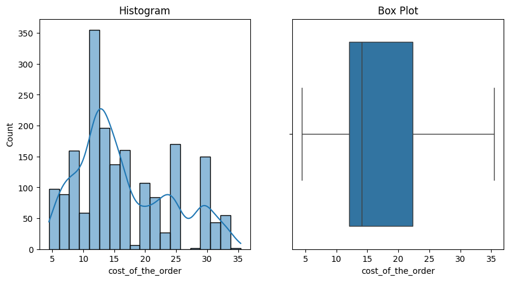

```python
# Write the code here

# Histogram and boxplots of 'cost_of_the_order' column

# Create a figure with two subplots
fig, (ax1, ax2) = plt.subplots(1, 2, figsize=(10, 5))

# Create the histogram on the first subplot with KDE
sns.histplot(data=df['cost_of_the_order'], ax=ax1, kde=True)
ax1.set_title('Histogram')

# Create the box plot on the second subplot
sns.boxplot(data=df['cost_of_the_order'], orient='h', ax=ax2)
ax2.set_title('Box Plot')

# Show the figure
plt.show()
```

##### Observations on 'food_preparation_time' column in the dataset

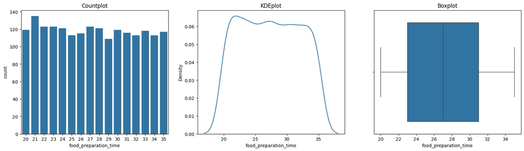

```python
# Write the code here

# Histogram and boxplots of 'food_preparation_time' column

# Create a figure with two subplots
fig, (ax1, ax2, ax3) = plt.subplots(1, 3, figsize=(20, 5))

# Create the countplot on the first subplot
sns.countplot(data=df,x='food_preparation_time', ax=ax1)
ax1.set_title('Countplot')

# Create the kdeplot on the second subplot
sns.kdeplot(data=df,x='food_preparation_time', ax=ax2)
ax2.set_title('KDEplot')

# Create the box plot on the third subplot
sns.boxplot(data=df['food_preparation_time'], orient='h', ax=ax3)
ax3.set_title('Boxplot')

# Show the figure
plt.show()
```

- The countplot, KDEplot and boxplots indicate an almost normal/uniform distribution for 'food_preparation_time' column
- No outliers are observed.
- From the statistics:
  - 75% of the orders were prepared in less than 31 minutes
  - Majority of the food was prepared between 20 minutes (minimum) and 35 minutes (maximum)

##### Observations on 'delivery_time' column in the dataset

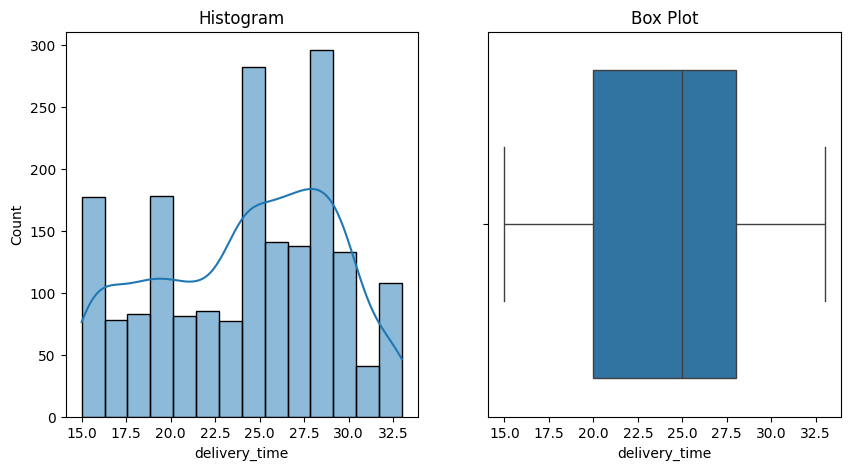

```python
# Write the code here

# Histogram and boxplots of 'delivery_time' column

# Create a figure with two subplots
fig, (ax1, ax2) = plt.subplots(1, 2, figsize=(10, 5))

# Create the histogram on the first subplot with KDE
sns.histplot(data=df['delivery_time'], ax=ax1, kde=True)
ax1.set_title('Histogram')

# Create the box plot on the second subplot
sns.boxplot(data=df['delivery_time'], orient='h', ax=ax2)
ax2.set_title('Box Plot')

# Show the figure
plt.show()
```

- The histogram and boxplots indicate very slight left skewness (almost normal) for 'delivery_time' column distribution
- No outliers are observed.
- From the statistics:
  - 75% of the orders were delivered in less than 28 minutes
  - Majority of the food was delivered between 15 minutes (minimum) and 33 minutes (maximum)

##### Observations on 'rating' columns

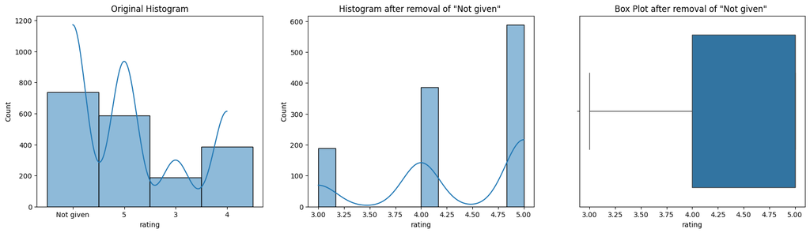

```python
# Suppress SettingWithCopyWarning warning
pd.set_option('mode.chained_assignment', None)

# Create a dataframe copy without values from 'rating' column that are 'Not given'
extracted_ratings_df = df[df['rating'] != 'Not given'];

#extracted_ratings_df.head()

#Converting the ratings column values to float and hence be plotted
extracted_ratings_df['rating'] = extracted_ratings_df['rating'].astype('float');

# Remove the suppressoin of SettingWithCopyWarning warning
pd.reset_option("mode.chained_assignment")

# Create a figure with two subplots
fig, (ax1, ax2, ax3) = plt.subplots(1, 3, figsize=(20, 5))

# Create the histogram on the first subplot with KDE
sns.histplot(data=df['rating'], ax=ax1, kde=True)
ax1.set_title('Original Histogram')

# Create the histogram on the second plot with extracted data
sns.histplot(data=extracted_ratings_df['rating'], ax=ax2, kde=True)
ax2.set_title('Histogram after removal of "Not given" ')

#Create the box plot on the third plot with extracted data
sns.boxplot(data=extracted_ratings_df['rating'], orient='h', ax=ax3)
ax3.set_title('Box Plot after removal of "Not given" ')

# Show the figure
plt.show()
```

#### **Observations on Categorical Columns**

##### Observations on 'day_of_the_week' column

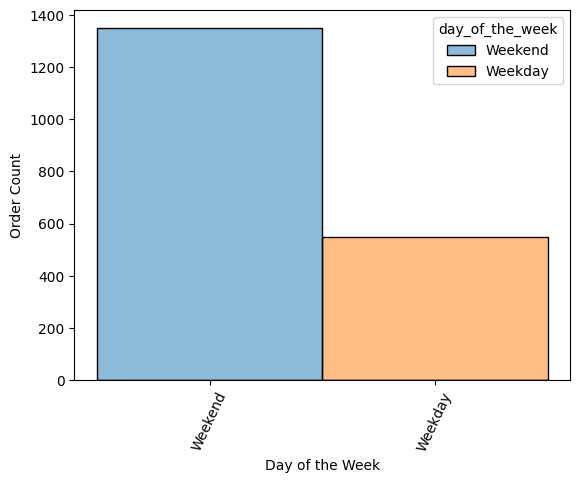

```python
sns.histplot(data=df,x='day_of_the_week',hue='day_of_the_week')
plt.ylabel("Order Count")
plt.xlabel("Day of the Week")
plt.xticks(rotation=65)
plt.show()
```

- From the histogram above, it is easily seen that orders on weekend are greater than those on weekdays
- Weekend orders = 1351, Weekday orders = 547
- Further categorization/granularity in weekdays & weekends can help in managing supply & demand (Monday - Sunday) for FoodHub.

##### Observations on 'cuisine_type'

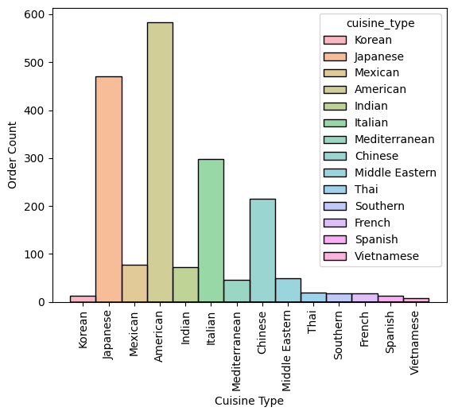

```python
sns.histplot(data=df,x='cuisine_type',hue='cuisine_type')
plt.ylabel("Order Count")
plt.xlabel("Cuisine Type")
plt.xticks(rotation=90)
plt.show()
```

- American cuisine orders followed by Japanese, Italian and Chinese cuisine orders were preferred by most customers.
- Vietnamese, Spanish, Korean, Southern, French and Thai cuisines were relatively less preferred in the dataset.

### **Question 7**: Which are the top 5 restaurants in terms of the number of orders received? [1 mark]

```python
# Write the code here

#group by restaurant_name, count, sort in descending order and print top 5
df.groupby('restaurant_name')['restaurant_name'].count().sort_values(ascending=False).head(5)
```

| restaurant_name | restaurant_name |
| --- | --- |
| Shake Shack | 219 |
| The Meatball Shop | 132 |
| Blue Ribbon Sushi | 119 |
| Blue Ribbon Fried Chicken | 96 |
| Parm | 68 |

**dtype:** int64

#### Observations:

- Top 5 restaurants:
  - Shake Shack - 219 Orders
  - The Meatball Shop - 132 Orders
  - Blue Ribbon Sushi - 119 Orders
  - Blue Ribbon Fried Chicken - 96 Orders
  - Parm - 68 Orders

### **Question 8**: Which is the most popular cuisine on weekends? [1 mark]

```python
# Write the code here
# filter day_of_the_week for Weekend, group by cuisine_type, count, sort in descending order and print top 1

df[df['day_of_the_week'] == 'Weekend'].groupby('cuisine_type')['cuisine_type'].count().sort_values(ascending=False).head(1)
```

| cuisine_type | cuisine_type |
| --- | --- |
| American | 415 |

**dtype:** int64

#### Observations:

- American cuisine_type received 415 orders on Weekend

### **Question 9**: What percentage of the orders cost more than 20 dollars? [2 marks]

```python
# Write the code here
# Total orders that are over 20 dollars
total_orders_over_20 = df[df['cost_of_the_order'] > 20].shape[0]
#print(total_orders_over_20)

# Total orders
total_orders = df.shape[0]
#print(total_orders)

# Calcluate percentage of orders over 20 dollars
percentage_over_20 = round( ( (total_orders_over_20 / total_orders) * 100 ), 2)

print(f"Percentage of orders over 20 dollars: {percentage_over_20:}%")
```

```
Percentage of orders over 20 dollars: 29.24%
```

#### Observations:

- 29.24% of orders are greater than 20 dollars in the dataset

### **Question 10**: What is the mean order delivery time? [1 mark]

```python
# Write the code here
# Mean delivery_time
mean_delivery_time = round(df['delivery_time'].mean(),2)
print(f"Mean delivery time: {mean_delivery_time} minutes")
```

```
Mean delivery time: 24.16 minutes
```

#### Observations:

- Mean delivery time (after the order was prepared) = 24.16 minutes

### **Question 11:** The company has decided to give 20% discount vouchers to the top 3 most frequent customers. Find the IDs of these customers and the number of orders they placed. [1 mark]

```python
# Write the code here
# Top three frequent customers - group by customer_id, count and sort
df.groupby('customer_id')['customer_id'].count().sort_values(ascending=False).head(3)
```

| customer_id | customer_id |
| --- | --- |
| 52832 | 13 |
| 47440 | 10 |
| 83287 | 9 |

**dtype:** int64

### **Question 12**: Perform a multivariate analysis to explore relationships between the important variables in the dataset. (It is a good idea to explore relations between numerical variables as well as relations between numerical and categorical variables) [10 marks]

##### Cusine Type vs Rating Vs Order Count

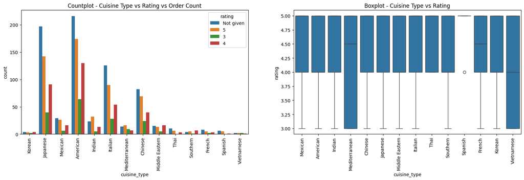

```python
# Write the code here

# Create a figure with two subplots
fig, (ax1, ax2) = plt.subplots(1, 2, figsize=(20, 5))

# Create the countplot on the first subplot
sns.countplot(data=df, ax=ax1, x='cuisine_type', hue='rating')
ax1.tick_params(axis='x', rotation=90)
ax1.set_title('Countplot - Cuisine Type vs Rating vs Order Count')

#create a boxplot between 'cuisine_type' and 'rating'
sns.boxplot(data=extracted_ratings_df, x='cuisine_type', y='rating', ax=ax2)
ax2.tick_params(axis='x', rotation=90)
ax2.set_title('Boxplot - Cuisine Type vs Rating')

# Show the figure
plt.show()
```

- From the above plots:
  - It is evident that almost all cuisines have orders that have not been rated. This might be an opportunity for incentivizing the consumer and receive ratings.
  - Foodhub probably can use this to analyze which restaurants have been consistently rated and make improvements based on learnings.
  - Spanish cuisine has an outlier

#### Cuisine Type and Cost of the Order

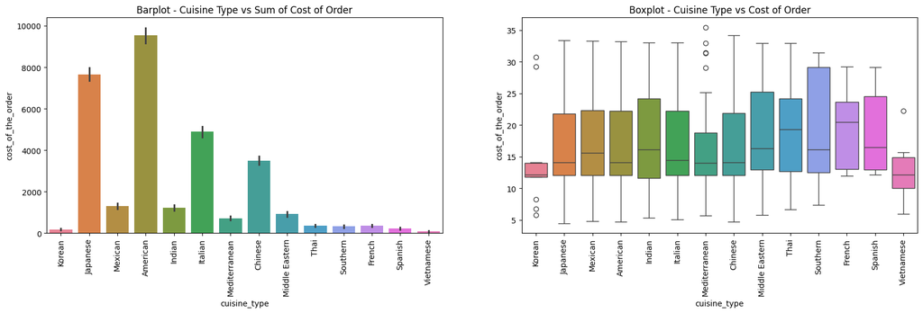

```python
# Write the code here
# Create a figure with two subplots
fig, (ax1, ax2) = plt.subplots(1, 2, figsize=(20, 5))

# Create the barplot on the first subplot
sns.barplot(data=df, x='cuisine_type', y='cost_of_the_order', ax=ax1, estimator='sum', hue='cuisine_type')
ax1.tick_params(axis='x', rotation=90)
ax1.set_title('Barplot - Cuisine Type vs Sum of Cost of Order')

#create a boxplot between 'cuisine_type' and 'rating'
sns.boxplot(data=df, x='cuisine_type', y='cost_of_the_order', ax=ax2, hue='cuisine_type')
ax2.tick_params(axis='x', rotation=90)
ax2.set_title('Boxplot - Cuisine Type vs Cost of Order')

# Show the figure
plt.show()
```

#### Cusine Type vs Day of the Week vs Order Count

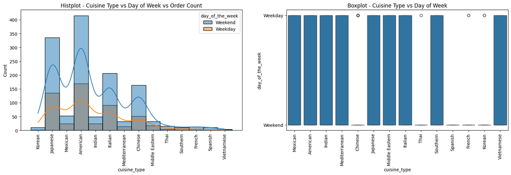

```python
# Write the code here

# Create a figure with two subplots
fig, (ax1, ax2) = plt.subplots(1, 2, figsize=(20, 5))

# Create the histogram on the first subplot
sns.histplot(data=df, ax=ax1, x='cuisine_type', hue='day_of_the_week',kde=True)
ax1.tick_params(axis='x', rotation=90)
ax1.set_title('Histplot - Cuisine Type vs Day of Week vs Order Count')

#create a boxplot between 'cuisine_type' and 'rating'
sns.boxplot(data=extracted_ratings_df, x='cuisine_type', y='day_of_the_week', ax=ax2)
ax2.tick_params(axis='x', rotation=90)
ax2.set_title('Boxplot - Cuisine Type vs Day of Week')

# Show the figure
plt.show()
```

- From the Histplot:
  - It can be seen that American, Japanese, Italian and Chinese had relatively a lot of orders during the weekdays and weekends
  - Weekday orders were less than weekend orders for all cuisines
  - This might be an opportunity to introduce further granularity on weekdays & weekends (Monday to Sunday) for further analysis.
- From the Boxplot outliers were noted for Chinese, Thai, French and Korean cuisine types and might need further analysis.

#### Day of the Week vs Time for Delivery

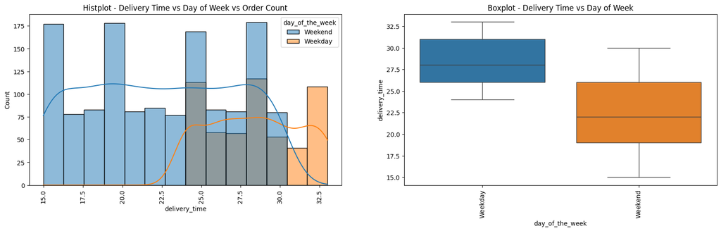

```python
# Write the code here

# Create a figure with two subplots
fig, (ax1, ax2) = plt.subplots(1, 2, figsize=(20, 5))

# Create the histogram on the first subplot
sns.histplot(data=df, ax=ax1, x='delivery_time', hue='day_of_the_week', kde=True)
ax1.tick_params(axis='x', rotation=90)
ax1.set_title('Histplot - Delivery Time vs Day of Week vs Order Count')

#create a boxplot between 'Day of the week' and 'Delivery Time'
sns.boxplot(data=extracted_ratings_df, x='day_of_the_week', y='delivery_time', hue='day_of_the_week', ax=ax2)
ax2.tick_params(axis='x', rotation=90)
ax2.set_title('Boxplot - Delivery Time vs Day of Week')

# Show the figure
plt.show()
```

- From the histplot and box plots it is seen that:
  - Delivery times are higher during weekdays when compared to weekends - This could be due to availability of more delivery drivers (flexible workforce) on weekends.
  - Maybe we should check the total order delivery times to dig a little deeper

#### Day of the Week vs Total Order Delivery Time

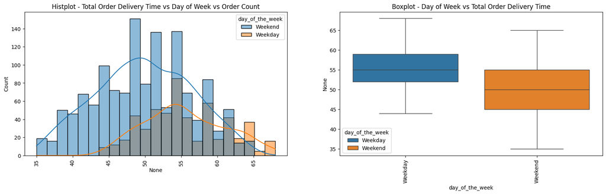

```python
# Write the code here

# Create a figure with two subplots
fig, (ax1, ax2) = plt.subplots(1, 2, figsize=(20, 5))

# Create the histogram on the first subplot
sns.histplot(data=df, ax=ax1, x=df['food_preparation_time']+df['delivery_time'], hue='day_of_the_week',kde=True)
ax1.tick_params(axis='x', rotation=90)
ax1.set_title('Histplot - Total Order Delivery Time vs Day of Week vs Order Count')

#create a boxplot between 'Day of the week' and 'Delivery Time'
sns.boxplot(data=extracted_ratings_df, x='day_of_the_week', y=df['food_preparation_time']+df['delivery_time'], hue='day_of_the_week', ax=ax2)
ax2.tick_params(axis='x', rotation=90)
ax2.set_title('Boxplot - Day of Week vs Total Order Delivery Time' )

# Show the figure
plt.show()
```

- From the histplot it is seen that the distributions for total order delivery times are almost normal (but a little skewed to the right).
- Food preparation and delivery times both probably benefit due presence of flexible workforce during weekends.

#### Cusine Type and Number of Restaurants

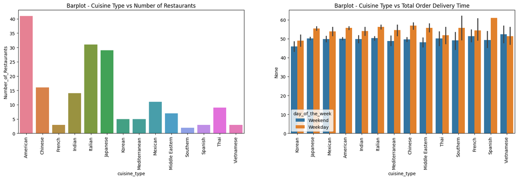

```
      cuisine_type  Number_of_Restaurants
0         American                     41
4          Italian                     31
5         Japanese                     29
1          Chinese                     16
3           Indian                     14
8          Mexican                     11
12            Thai                      9
9   Middle Eastern                      7
6           Korean                      5
7    Mediterranean                      5
2           French                      3
11         Spanish                      3
13      Vietnamese                      3
10        Southern                      2
```

```python
# Create a histplot with 'Cuisine Type' and Number of Restaurants for each cuisine type
Number_of_Restaurants = df.groupby('cuisine_type')['restaurant_name'].nunique().reset_index()
Number_of_Restaurants.columns = ['cuisine_type', 'Number_of_Restaurants']

#Number_of_Restaurants.head()

# Create a figure with two subplots
fig, (ax1, ax2) = plt.subplots(1, 2, figsize=(20, 5))

sns.barplot(data=Number_of_Restaurants, x='cuisine_type', y='Number_of_Restaurants',hue='cuisine_type', ax=ax1)
ax1.tick_params(axis='x', rotation=90)
ax1.set_title('Barplot - Cuisine Type vs Number of Restaurants')

#create a barplot between 'cuisine_type' and 'Total Delivery Time'
sns.barplot(data=df, x='cuisine_type', y=df['food_preparation_time']+df['delivery_time'], hue='day_of_the_week', ax=ax2)
ax2.tick_params(axis='x', rotation=90)
ax2.set_title('Barplot - Cuisine Type vs Total Order Delivery Time' )

#sns.barplot(data=df, x=df['cuisine_type'], y=df['delivery_time'], hue='day_of_the_week', ax=ax2)
#sns.barplot(data=df, x='cuisine_type', y=df['food_preparation_time'], hue='day_of_the_week', ax=ax2)

# Show the figure
plt.show()

print(Number_of_Restaurants.sort_values(by=['Number_of_Restaurants'], ascending=False))
```

- From the barplot for "Number of Restaurants vs Cuisine Type", it is seen that:
  - American, Italian, Japanese, Indian and Mexican cuisines have more than 10 restaurants registered in FoodHub.
  - We might be tempted to infer that presence of higher number of restaurants in these cuisines types would lead to better total delivery times due to more options.
- From the barplot for "Cuisine Type vs Total Order Delivery Time" it can be seen that the total delivery times are mostly uniform across the cuisine types.

#### Cuisine Type vs Food Preparation Time

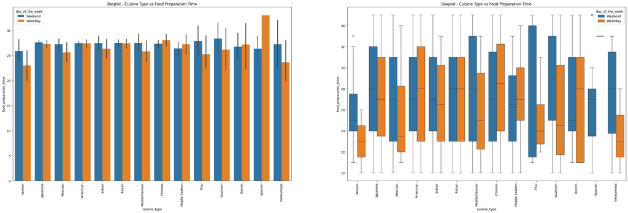

```python
# Relationship between food preparation time and cuisine type

# Create a figure with two subplots
fig, (ax1, ax2) = plt.subplots(1, 2, figsize=(35, 10))

sns.barplot(data=df, x='cuisine_type', y=df['food_preparation_time'], hue='day_of_the_week',ax=ax1)
ax1.tick_params(axis='x', rotation=90)
ax1.set_title('Barplot - Cuisine Type vs Food Preparation Time')

#create a barplot between 'cuisine_type' and 'Total Delivery Time'
sns.boxplot(data=df, x='cuisine_type', y='food_preparation_time',hue='day_of_the_week',ax=ax2)
ax2.tick_params(axis='x', rotation=90)
ax2.set_title('Boxplot - Cuisine Type vs Food Preparation Time' )
```

#### Cost of the Order vs Food Preparation Time vs Delivery Time vs Rating

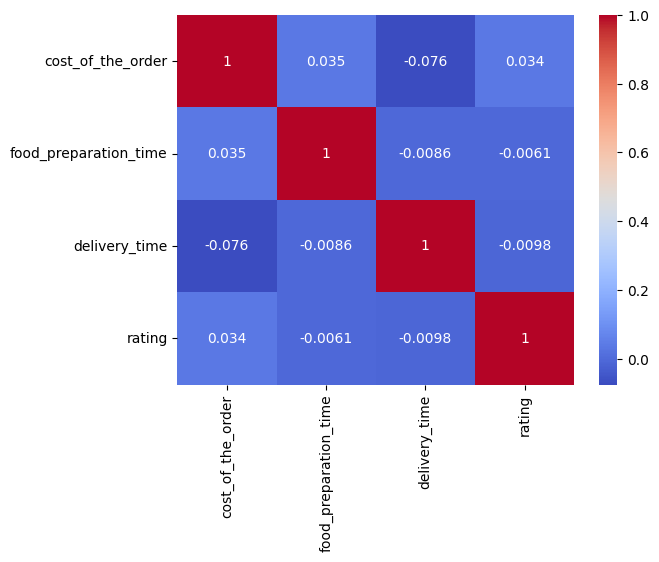

```python
#plot the correlation matrix
corr_matrix = extracted_ratings_df[['cost_of_the_order', 'food_preparation_time', 'delivery_time','rating']].corr()
sns.heatmap(corr_matrix, annot=True, cmap='coolwarm')
plt.show()
```

### **Question 13:** The company wants to provide a promotional offer in the advertisement of the restaurants. The condition to get the offer is that the restaurants must have a rating count of more than 50 and the average rating should be greater than 4. Find the restaurants fulfilling the criteria to get the promotional offer. [3 marks]

```python
# Reuse the previously created extracted_ratings_df in observations for 'ratings' column
# Group by restaurant name and calculate both count and average
ratings_calculated = extracted_ratings_df.groupby('restaurant_name')['rating'].aggregate(['mean', 'count']).sort_values(by='count', ascending=False)

#print(ratings_calculated)

# Filter for restaurants with more than 50 ratings and an average rating greater than 4.
restaurants_shortlisted_promotion = ratings_calculated[(ratings_calculated['count'] > 50) & (ratings_calculated['mean'] > 4)]

# Display the promotional restaurants
print(restaurants_shortlisted_promotion)
```

```
                               mean  count
restaurant_name
Shake Shack                4.278195    133
The Meatball Shop          4.511905     84
Blue Ribbon Sushi          4.219178     73
Blue Ribbon Fried Chicken  4.328125     64
```

#### Observations:

- We reused the extracted ratings (without 'Not given' ratings) and found that only four restaurants were eligible for the promotion:
  - Shake Shack (133 ratings)
  - The Meatball Shop (84 ratings)
  - Blue Ribbon Sushi (73 ratings)
  - Blue Ribbon Fried Chicken (64 ratings)

### **Question 14:** The company charges the restaurant 25% on the orders having cost greater than 20 dollars and 15% on the orders having cost greater than 5 dollars. Find the net revenue generated by the company across all orders. [3 marks]

```python
# Write the code here
Charge1 = 0.25 # For orders > $20
Charge2 = 0.15 # For orders > $5 & <= $20

#Total of all orders costs greater than $20
Total1 = df['cost_of_the_order'][ df['cost_of_the_order'] > 20].sort_values(ascending=False).sum()
Net_Revenue1 = Total1 * Charge1

#Total of all orders costs greater than $5 but less than or equal to $20
Total2 = df['cost_of_the_order'][ (df['cost_of_the_order'] >5) & (df['cost_of_the_order'] <= 20)].sort_values(ascending=False).sum()
Net_Revenue2 = Total2 * Charge2

#Net revenue generated by the company across all orders
print(f"Net Revenue Generated = { Net_Revenue1 + Net_Revenue2 } dollars")
```

```
Net Revenue Generated = 6166.303 dollars
```

#### Observations:

- Net Revenue of 6166.303 dollars is generated by the company across all orders

### **Question 15:** The company wants to analyze the total time required to deliver the food. What percentage of orders take more than 60 minutes to get delivered from the time the order is placed? (The food has to be prepared and then delivered.) [2 marks]

```python
# Write the code here

# Total time required to deliver food = 'food_preparation_time' + 'delivery_time'
total_time_required = df['food_preparation_time'] + df['delivery_time']
#print(total_time_required.shape[0])

# Total orders that take more than 60 minutes to deliver
total_orders_over_60 = total_time_required[total_time_required > 60]
#print(total_orders_over_60.shape[0])

percentage_over_60 =  ( (total_orders_over_60.shape[0] / total_time_required.shape[0]) * 100 )
print(f"Percentage of orders that take greater than 60 minutes = {percentage_over_60}%")
```

```
Percentage of orders that take greater than 60 minutes = 10.537407797681771%
```

#### Observations:

- Percentage of orders that take greater than 60 minutes = 10.537%

### **Question 16:** The company wants to analyze the delivery time of the orders on weekdays and weekends. How does the mean delivery time vary during weekdays and weekends? [2 marks]

```python
# Write the code here

#mean 'delivery_time' on 'day_of_the_week' on weekdays
mean_weekday_delivery_time = df[df['day_of_the_week'] == 'Weekday']['delivery_time'].mean()
print(f"Mean delivery time on weekdays = {mean_weekday_delivery_time} minutes")

#mean 'delivery_time' on 'day_of_the_week' on weekends
mean_weekend_delivery_time = df[df['day_of_the_week'] == 'Weekend']['delivery_time'].mean()
print(f"Mean delivery time on weekends = {mean_weekend_delivery_time} minutes")

print(f"Delivery time difference between weekdays and weekends = {round(mean_weekday_delivery_time - mean_weekend_delivery_time,2)} minutes")
print(f"Delivery time percentage difference between weekdays and weekends = {round((mean_weekday_delivery_time-mean_weekend_delivery_time)/mean_weekend_delivery_time *100,2)}%")
```

```
Mean delivery time on weekdays = 28.340036563071298 minutes
Mean delivery time on weekends = 22.4700222057735 minutes
Delivery time difference between weekdays and weekends = 5.87 minutes
Delivery time percentage difference between weekdays and weekends = 26.12%
```

#### Observations:

- Mean delivery time on weekdays = 28.34 minutes
- Mean delivery time on weekends = 22.47 minutes
- Delivery time percentage difference between weekends & weekdays = 26.12%

### Conclusion and Recommendations

### **Question 17:** What are your conclusions from the analysis? What recommendations would you like to share to help improve the business? (You can use cuisine type and feedback ratings to drive your business recommendations.) [6 marks]

### Conclusions:

**Dataset:**

- The dataset had no missing or duplicate values (exception was with ratings of "Not given")

**Order Timing and Trends**

- Weekends saw higher order activity (1351 orders) compared to weekdays (547 orders).
- Food preparation times were slightly lower on weekdays compared to weekends for most cuisines.
- Delivery times were higher on weekdays (mean: 28.34 minutes) than on weekends (mean: 22.47 minutes), possibly due to workforce availability.

**Order Cost and Ratings**

**Preparation and Delivery Times**

- Minimum preparation time: 20 minutes; maximum: 35 minutes; average: 27.37 minutes
- 75% of orders were prepared in under 31 minutes.
- Delivery times were mostly uniform across cuisine types, with 75% of orders delivered in under 28 minutes.
- Approximately 10.54% of orders took more than 60 minutes to complete.
- "**Total delivery times**" showed a near-normal distribution, slightly skewed to the right

**Revenue**

- Net revenue generated was $6166.30 across all orders.
- American, Japanese, Italian, and Chinese cuisines contributed the most revenue, while Vietnamese, Korean, Spanish, Southern, Thai, and French cuisines contributed the least

### Recommendations:

**2. Customer Ratings Improvement:**

- Incentivize customers to provide ratings, particularly for unrated orders (736 instances), to gather more comprehensive feedback.
- Analyze restaurants with consistent ratings to derive best practices and replicate them across other restaurants.

**3. Weekday and Weekend Strategy:**

- Implement further granularity in data collection (e.g., analyze trends by individual weekdays and weekends) to better manage supply and demand.
- Adjust workforce allocation during weekdays to reduce delivery times, aligning them closer to weekend efficiency levels.

**4. Revenue Maximization:**

- Promote cuisines that generate the most revenue (American, Japanese, Italian, and Chinese) through targeted campaigns and discounts.
- Investigate reasons for lower revenue contributions from Vietnamese, Korean, Spanish, Southern, Thai, and French cuisines and consider strategies like bundled offers or promotions.

**5. Data-Driven Insights:**

- Explore external factors influencing weak correlations (e.g., weather, traffic, or promotions) to uncover hidden patterns.
- Conduct deeper analyses on customer satisfaction to understand why delivery times and preparation times have minimal impact on ratings.

**6. Operational Enhancements:**

- Use predictive analytics to optimize food preparation and delivery times based on historical trends.
- Suggest implementation of quality control measures for restaurants with higher preparation time variability or frequent outliers.

By focusing on these recommendations, FoodHub can enhance customer experience, improve operational efficiency, and maximize revenue.